# Project: Investigate a Soccer Dataset

- Introduction
- Data Wrangling
- Exploratory Data Analysis
- Conclusions

## Overview

> **The investigation will be based on the following questions:**
> 1. Which are the best free kick takers - Left or Right footed players?
> 2. Is there a relationship between acceleration, height and weight?
> 3. Which teams got the most points per game between the 2012/13 - 2015/16 seasons?

```python
import numpy as np
import pandas as pd
import datetime as dt
import sqlite3
from mpl_toolkits.mplot3d import Axes3D
import matplotlib.pyplot as plt
import seaborn as sns
from IPython.display import display
```

## Data Wrangling

Here we view all table data and import 4 tables to create 2 dataframes.

Dataframe 1 combines Players and Players Attributes which is used to find the average free kick taking score for left and right footed players together with long shooting data. This same dataframe will be used to build a scatter chart and examine the relationship between acceleration, height and weight.

Dataframe 2 includes the Match and Team tables and both will be used to analyze Team Performance across different seasons.

### General Properties

```python
# Creating connection with sqlite database.
conn = sqlite3.connect("database.sqlite")
cur = conn.cursor()
cur.execute("SELECT name FROM sqlite_master WHERE type='table';");

# Printing table names from dataset.
results = cur.fetchall()
print(results)
```

```
[('sqlite_sequence',), ('Player_Attributes',), ('Player',), ('Match',), ('League',), ('Country',), ('Team',), ('Team_Attributes',)]
```

```python
# Loading data
sequence = pd.read_sql_query("SELECT * from sqlite_sequence", conn)
player_attributes = pd.read_sql_query("SELECT * from Player_Attributes", conn)
players = pd.read_sql_query("SELECT * from Player", conn)
countries = pd.read_sql_query("SELECT * from Country", conn)
matches = pd.read_sql_query("SELECT * from Match", conn)
leagues = pd.read_sql_query("SELECT * from League", conn)
teams = pd.read_sql_query("SELECT * from Team", conn)
team_attributes = pd.read_sql_query("SELECT * from Team_Attributes", conn)
```

```python
# Printing 'sqlite_sequence' table which returns names and row count for all tables.
sequence.head()
```

|  | name | seq |
| --- | --- | --- |
| 0 | Team | 103916 |
| 1 | Country | 51958 |
| 2 | League | 51958 |
| 3 | Match | 51958 |
| 4 | Player | 11075 |

```python
# Printing 'Player_Attributes' table.
player_attributes.head()
```

|  | id | player_fifa_api_id | player_api_id | date | overall_rating | potential | preferred_foot | attacking_work_rate | defensive_work_rate | crossing | ... | vision | penalties | marking | standing_tackle | sliding_tackle | gk_diving | gk_handling | gk_kicking | gk_positioning | gk_reflexes |
| --- | --- | --- | --- | --- | --- | --- | --- | --- | --- | --- | --- | --- | --- | --- | --- | --- | --- | --- | --- | --- | --- |
| 0 | 1 | 218353 | 505942 | 2016-02-18 00:00:00 | 67.0 | 71.0 | right | medium | medium | 49.0 | ... | 54.0 | 48.0 | 65.0 | 69.0 | 69.0 | 6.0 | 11.0 | 10.0 | 8.0 | 8.0 |
| 1 | 2 | 218353 | 505942 | 2015-11-19 00:00:00 | 67.0 | 71.0 | right | medium | medium | 49.0 | ... | 54.0 | 48.0 | 65.0 | 69.0 | 69.0 | 6.0 | 11.0 | 10.0 | 8.0 | 8.0 |
| 2 | 3 | 218353 | 505942 | 2015-09-21 00:00:00 | 62.0 | 66.0 | right | medium | medium | 49.0 | ... | 54.0 | 48.0 | 65.0 | 66.0 | 69.0 | 6.0 | 11.0 | 10.0 | 8.0 | 8.0 |
| 3 | 4 | 218353 | 505942 | 2015-03-20 00:00:00 | 61.0 | 65.0 | right | medium | medium | 48.0 | ... | 53.0 | 47.0 | 62.0 | 63.0 | 66.0 | 5.0 | 10.0 | 9.0 | 7.0 | 7.0 |
| 4 | 5 | 218353 | 505942 | 2007-02-22 00:00:00 | 61.0 | 65.0 | right | medium | medium | 48.0 | ... | 53.0 | 47.0 | 62.0 | 63.0 | 66.0 | 5.0 | 10.0 | 9.0 | 7.0 | 7.0 |

5 rows × 42 columns

```python
# previewing 'Player' table.
players.head(5)
```

|  | id | player_api_id | player_name | player_fifa_api_id | birthday | height | weight |
| --- | --- | --- | --- | --- | --- | --- | --- |
| 0 | 1 | 505942 | Aaron Appindangoye | 218353 | 1992-02-29 00:00:00 | 182.88 | 187 |
| 1 | 2 | 155782 | Aaron Cresswell | 189615 | 1989-12-15 00:00:00 | 170.18 | 146 |
| 2 | 3 | 162549 | Aaron Doran | 186170 | 1991-05-13 00:00:00 | 170.18 | 163 |
| 3 | 4 | 30572 | Aaron Galindo | 140161 | 1982-05-08 00:00:00 | 182.88 | 198 |
| 4 | 5 | 23780 | Aaron Hughes | 17725 | 1979-11-08 00:00:00 | 182.88 | 154 |

```python
# Printing 'Match' table.
matches.head()
```

|  | id | country_id | league_id | season | stage | date | match_api_id | home_team_api_id | away_team_api_id | home_team_goal | ... | SJA | VCH | VCD | VCA | GBH | GBD | GBA | BSH | BSD | BSA |
| --- | --- | --- | --- | --- | --- | --- | --- | --- | --- | --- | --- | --- | --- | --- | --- | --- | --- | --- | --- | --- | --- |
| 0 | 1 | 1 | 1 | 2008/2009 | 1 | 2008-08-17 00:00:00 | 492473 | 9987 | 9993 | 1 | ... | 4.00 | 1.65 | 3.40 | 4.50 | 1.78 | 3.25 | 4.00 | 1.73 | 3.40 | 4.20 |
| 1 | 2 | 1 | 1 | 2008/2009 | 1 | 2008-08-16 00:00:00 | 492474 | 10000 | 9994 | 0 | ... | 3.80 | 2.00 | 3.25 | 3.25 | 1.85 | 3.25 | 3.75 | 1.91 | 3.25 | 3.60 |
| 2 | 3 | 1 | 1 | 2008/2009 | 1 | 2008-08-16 00:00:00 | 492475 | 9984 | 8635 | 0 | ... | 2.50 | 2.35 | 3.25 | 2.65 | 2.50 | 3.20 | 2.50 | 2.30 | 3.20 | 2.75 |
| 3 | 4 | 1 | 1 | 2008/2009 | 1 | 2008-08-17 00:00:00 | 492476 | 9991 | 9998 | 5 | ... | 7.50 | 1.45 | 3.75 | 6.50 | 1.50 | 3.75 | 5.50 | 1.44 | 3.75 | 6.50 |
| 4 | 5 | 1 | 1 | 2008/2009 | 1 | 2008-08-16 00:00:00 | 492477 | 7947 | 9985 | 1 | ... | 1.73 | 4.50 | 3.40 | 1.65 | 4.50 | 3.50 | 1.65 | 4.75 | 3.30 | 1.67 |

5 rows × 115 columns

```python
# Printing 'League' table.
leagues.head()
```

|  | id | country_id | name |
| --- | --- | --- | --- |
| 0 | 1 | 1 | Belgium Jupiler League |
| 1 | 1729 | 1729 | England Premier League |
| 2 | 4769 | 4769 | France Ligue 1 |
| 3 | 7809 | 7809 | Germany 1. Bundesliga |
| 4 | 10257 | 10257 | Italy Serie A |

```python
# Printing 'Country' table.
countries.head()
```

|  | id | name |
| --- | --- | --- |
| 0 | 1 | Belgium |
| 1 | 1729 | England |
| 2 | 4769 | France |
| 3 | 7809 | Germany |
| 4 | 10257 | Italy |

```python
# Printing 'Team' table.
teams.head()
```

|  | id | team_api_id | team_fifa_api_id | team_long_name | team_short_name |
| --- | --- | --- | --- | --- | --- |
| 0 | 1 | 9987 | 673.0 | KRC Genk | GEN |
| 1 | 2 | 9993 | 675.0 | Beerschot AC | BAC |
| 2 | 3 | 10000 | 15005.0 | SV Zulte-Waregem | ZUL |
| 3 | 4 | 9994 | 2007.0 | Sporting Lokeren | LOK |
| 4 | 5 | 9984 | 1750.0 | KSV Cercle Brugge | CEB |

```python
# Printing 'Team_Attributes' table.
team_attributes.head(4)
```

|  | id | team_fifa_api_id | team_api_id | date | buildUpPlaySpeed | buildUpPlaySpeedClass | buildUpPlayDribbling | buildUpPlayDribblingClass | buildUpPlayPassing | buildUpPlayPassingClass | ... | chanceCreationShooting | chanceCreationShootingClass | chanceCreationPositioningClass | defencePressure | defencePressureClass | defenceAggression | defenceAggressionClass | defenceTeamWidth | defenceTeamWidthClass | defenceDefenderLineClass |
| --- | --- | --- | --- | --- | --- | --- | --- | --- | --- | --- | --- | --- | --- | --- | --- | --- | --- | --- | --- | --- | --- |
| 0 | 1 | 434 | 9930 | 2010-02-22 00:00:00 | 60 | Balanced | NaN | Little | 50 | Mixed | ... | 55 | Normal | Organised | 50 | Medium | 55 | Press | 45 | Normal | Cover |
| 1 | 2 | 434 | 9930 | 2014-09-19 00:00:00 | 52 | Balanced | 48.0 | Normal | 56 | Mixed | ... | 64 | Normal | Organised | 47 | Medium | 44 | Press | 54 | Normal | Cover |
| 2 | 3 | 434 | 9930 | 2015-09-10 00:00:00 | 47 | Balanced | 41.0 | Normal | 54 | Mixed | ... | 64 | Normal | Organised | 47 | Medium | 44 | Press | 54 | Normal | Cover |
| 3 | 4 | 77 | 8485 | 2010-02-22 00:00:00 | 70 | Fast | NaN | Little | 70 | Long | ... | 70 | Lots | Organised | 60 | Medium | 70 | Double | 70 | Wide | Cover |

4 rows × 25 columns

```python
#merging 'Player' & 'Player_attributes' tables
df1_players = pd.read_sql_query("SELECT PA.player_api_id, P.player_name, P.height, P.weight, PA.acceleration, PA.preferred_foot, PA.free_kick_accuracy, PA.long_shots FROM Player_Attributes AS PA INNER JOIN Player AS P ON PA.player_api_id = P.player_api_id;", conn)
df1_players.head()
```

|  | player_api_id | player_name | height | weight | acceleration | preferred_foot | free_kick_accuracy | long_shots |
| --- | --- | --- | --- | --- | --- | --- | --- | --- |
| 0 | 505942 | Aaron Appindangoye | 182.88 | 187 | 60.0 | right | 39.0 | 35.0 |
| 1 | 505942 | Aaron Appindangoye | 182.88 | 187 | 60.0 | right | 39.0 | 35.0 |
| 2 | 505942 | Aaron Appindangoye | 182.88 | 187 | 60.0 | right | 39.0 | 35.0 |
| 3 | 505942 | Aaron Appindangoye | 182.88 | 187 | 60.0 | right | 38.0 | 34.0 |
| 4 | 505942 | Aaron Appindangoye | 182.88 | 187 | 60.0 | right | 38.0 | 34.0 |

```python
#merging 'Team' table with goals scored and team data from 'Match' table
df2_TP = pd.read_sql_query("SELECT t.*, m.season, m.match_api_id, m.home_team_api_id, m.away_team_api_id, m.home_team_goal, m.away_team_goal FROM Team t, Match m WHERE t.team_api_id = m.home_team_api_id OR t.team_api_id = m.away_team_api_id", conn)
df2_TP.head()
```

|  | id | team_api_id | team_fifa_api_id | team_long_name | team_short_name | season | match_api_id | home_team_api_id | away_team_api_id | home_team_goal | away_team_goal |
| --- | --- | --- | --- | --- | --- | --- | --- | --- | --- | --- | --- |
| 0 | 1 | 9987 | 673.0 | KRC Genk | GEN | 2008/2009 | 492473 | 9987 | 9993 | 1 | 1 |
| 1 | 2 | 9993 | 675.0 | Beerschot AC | BAC | 2008/2009 | 492473 | 9987 | 9993 | 1 | 1 |
| 2 | 4 | 9994 | 2007.0 | Sporting Lokeren | LOK | 2008/2009 | 492474 | 10000 | 9994 | 0 | 0 |
| 3 | 3 | 10000 | 15005.0 | SV Zulte-Waregem | ZUL | 2008/2009 | 492474 | 10000 | 9994 | 0 | 0 |
| 4 | 6 | 8635 | 229.0 | RSC Anderlecht | AND | 2008/2009 | 492475 | 9984 | 8635 | 0 | 3 |

### Observations from the dataset

> 1.) For questions 1 and 2 I created df1 which includes player data together with other attributes. Currently df1 has well over 183,000 rows due to many entries for the same players entered on different dates. For the scope of my research I am going to drop these duplicate values.

> 2.) Df2 which will be used for question 3 does not include the number of points and games played. Hence I need to calculate the number of wins, draws and loses for each team to be able to get the required information to discover which teams got the most points during the 2012/13 - 2015/16 seasons.

### 1.) Cleaning Dataframe 1

```python
#removing duplicates based on player api id
df1 = df1_players.drop_duplicates(['player_api_id'])
df1.describe()
```

|  | player_api_id | height | weight | acceleration | free_kick_accuracy | long_shots |
| --- | --- | --- | --- | --- | --- | --- |
| count | 11060.000000 | 11060.000000 | 11060.000000 | 11060.000000 | 11060.000000 | 11060.000000 |
| mean | 156582.427215 | 181.867445 | 168.380289 | 64.765642 | 48.195660 | 52.043761 |
| std | 160713.700624 | 6.369201 | 14.990217 | 14.044542 | 17.857927 | 18.434441 |
| min | 2625.000000 | 157.480000 | 117.000000 | 13.000000 | 4.000000 | 6.000000 |
| 25% | 35555.500000 | 177.800000 | 159.000000 | 55.000000 | 35.000000 | 40.000000 |
| 50% | 96619.500000 | 182.880000 | 168.000000 | 67.000000 | 49.000000 | 57.000000 |
| 75% | 212470.500000 | 185.420000 | 179.000000 | 75.000000 | 62.000000 | 66.000000 |
| max | 750584.000000 | 208.280000 | 243.000000 | 97.000000 | 94.000000 | 93.000000 |

### 2.) Cleaning Dataframe 2

```python
#cleaning dataframe to display all teams (team name, team api id), win/loss/draw records for each season, total points, games played and points per game for each year

#check number of unique values for each column
df2_TP.nunique()
```

```
id                    299
team_api_id           299
team_fifa_api_id      285
team_long_name        296
team_short_name       259
season                  8
match_api_id        25979
home_team_api_id      299
away_team_api_id      299
home_team_goal         11
away_team_goal         10
dtype: int64
```

```python
#check duplicated values
sum(df2_TP.duplicated())
```

```
0
```

```python
#Get winning pairs
df2_HW=df2_TP.query('team_api_id==home_team_api_id').query('home_team_goal > away_team_goal')
df2_AW=df2_TP.query('team_api_id==away_team_api_id').query('home_team_goal < away_team_goal')
df2_wins = pd.concat([df2_HW,df2_AW])
df2_wins.head()
```

|  | id | team_api_id | team_fifa_api_id | team_long_name | team_short_name | season | match_api_id | home_team_api_id | away_team_api_id | home_team_goal | away_team_goal |
| --- | --- | --- | --- | --- | --- | --- | --- | --- | --- | --- | --- |
| 6 | 7 | 9991 | 674.0 | KAA Gent | GEN | 2008/2009 | 492476 | 9991 | 9998 | 5 | 0 |
| 17 | 17 | 10001 | 681.0 | KVC Westerlo | WES | 2008/2009 | 492481 | 10001 | 9986 | 1 | 0 |
| 18 | 12 | 8342 | 231.0 | Club Brugge KV | CLB | 2008/2009 | 492564 | 8342 | 8571 | 4 | 1 |
| 42 | 5 | 9984 | 1750.0 | KSV Cercle Brugge | CEB | 2008/2009 | 492576 | 9984 | 10000 | 2 | 0 |
| 51 | 17 | 10001 | 681.0 | KVC Westerlo | WES | 2008/2009 | 492580 | 10001 | 9987 | 1 | 0 |

```python
#Get losing pairs
df2_HL=df2_TP.query('team_api_id==home_team_api_id').query('home_team_goal < away_team_goal')
df2_AL=df2_TP.query('team_api_id==away_team_api_id').query('home_team_goal > away_team_goal')
df2_losses = pd.concat([df2_HL,df2_AL])
df2_losses.head()
```

|  | id | team_api_id | team_fifa_api_id | team_long_name | team_short_name | season | match_api_id | home_team_api_id | away_team_api_id | home_team_goal | away_team_goal |
| --- | --- | --- | --- | --- | --- | --- | --- | --- | --- | --- | --- |
| 5 | 5 | 9984 | 1750.0 | KSV Cercle Brugge | CEB | 2008/2009 | 492475 | 9984 | 8635 | 0 | 3 |
| 8 | 9 | 7947 | NaN | FCV Dender EH | DEN | 2008/2009 | 492477 | 7947 | 9985 | 1 | 3 |
| 14 | 15 | 4049 | NaN | Tubize | TUB | 2008/2009 | 492480 | 4049 | 9996 | 1 | 2 |
| 20 | 10 | 9985 | 232.0 | Standard de Liège | STL | 2008/2009 | 492565 | 9985 | 9986 | 1 | 2 |
| 23 | 3 | 10000 | 15005.0 | SV Zulte-Waregem | ZUL | 2008/2009 | 492566 | 10000 | 9991 | 0 | 2 |

```python
# Get drawing pair
df2_HD=df2_TP.query('team_api_id==home_team_api_id').query('home_team_goal == away_team_goal')
df2_AD=df2_TP.query('team_api_id==away_team_api_id').query('home_team_goal == away_team_goal')
df2_draws = pd.concat([df2_HD,df2_AD])
df2_draws.head()
```

|  | id | team_api_id | team_fifa_api_id | team_long_name | team_short_name | season | match_api_id | home_team_api_id | away_team_api_id | home_team_goal | away_team_goal |
| --- | --- | --- | --- | --- | --- | --- | --- | --- | --- | --- | --- |
| 0 | 1 | 9987 | 673.0 | KRC Genk | GEN | 2008/2009 | 492473 | 9987 | 9993 | 1 | 1 |
| 3 | 3 | 10000 | 15005.0 | SV Zulte-Waregem | ZUL | 2008/2009 | 492474 | 10000 | 9994 | 0 | 0 |
| 10 | 11 | 8203 | 110724.0 | KV Mechelen | MEC | 2008/2009 | 492478 | 8203 | 8342 | 1 | 1 |
| 13 | 13 | 9999 | 546.0 | KSV Roeselare | ROS | 2008/2009 | 492479 | 9999 | 8571 | 2 | 2 |
| 24 | 4 | 9994 | 2007.0 | Sporting Lokeren | LOK | 2008/2009 | 492567 | 9994 | 9998 | 0 | 0 |

```python
# Drop unwanted columns
columns = ['id','team_fifa_api_id','team_short_name','home_team_api_id','away_team_api_id','home_team_goal','away_team_goal']
df2_wins.drop(columns, inplace=True, axis=1)
df2_losses.drop(columns, inplace=True, axis=1)
df2_draws.drop(columns, inplace=True, axis=1)
```

```python
# Create wins column and group by team & season
df2_wins.rename(columns={"match_api_id":"wins"}, inplace=True)
df2_wins_by_season=df2_wins.groupby(['team_api_id','season','team_long_name'], as_index=False).count()

# Create losses column and group by team & season
df2_losses.rename(columns={"match_api_id":"losses"}, inplace=True)
df2_losses_by_season=df2_losses.groupby(['team_api_id','season','team_long_name'], as_index=False).count()

# Create draws column and group by team & season
df2_draws.rename(columns={"match_api_id":"draws"}, inplace=True)
df2_draws_by_season=df2_draws.groupby(['team_api_id','season','team_long_name'], as_index=False).count()
```

```python
#merging all 3 dataframes together
df2_WL = pd.merge(df2_wins_by_season,df2_losses_by_season,how='inner',on=['team_api_id','season','team_long_name'])
df2_WDL = pd.merge(df2_WL,df2_draws_by_season,how='inner',on=['team_api_id','season','team_long_name'])

#previewing merged df
df2_WDL.head()
```

|  | team_api_id | season | team_long_name | wins | losses | draws |
| --- | --- | --- | --- | --- | --- | --- |
| 0 | 1601 | 2008/2009 | Ruch Chorzów | 9 | 14 | 7 |
| 1 | 1601 | 2009/2010 | Ruch Chorzów | 16 | 9 | 5 |
| 2 | 1601 | 2010/2011 | Ruch Chorzów | 10 | 12 | 8 |
| 3 | 1601 | 2011/2012 | Ruch Chorzów | 16 | 7 | 7 |
| 4 | 1601 | 2012/2013 | Ruch Chorzów | 8 | 15 | 7 |

```python
#create new column for games played
df2_WDL['games_played'] = df2_WDL['wins'] + df2_WDL['losses'] + df2_WDL['draws']

#create new column for points per team
df2_WDL['points'] = df2_WDL['wins']*3 + df2_WDL['draws']

#create points per game column
df2_WDL['points_per_game'] = df2_WDL['points']/df2_WDL['games_played']

#previewing new df
df2_WDL.head()
```

|  | team_api_id | season | team_long_name | wins | losses | draws | games_played | points | points_per_game |
| --- | --- | --- | --- | --- | --- | --- | --- | --- | --- |
| 0 | 1601 | 2008/2009 | Ruch Chorzów | 9 | 14 | 7 | 30 | 34 | 1.133333 |
| 1 | 1601 | 2009/2010 | Ruch Chorzów | 16 | 9 | 5 | 30 | 53 | 1.766667 |
| 2 | 1601 | 2010/2011 | Ruch Chorzów | 10 | 12 | 8 | 30 | 38 | 1.266667 |
| 3 | 1601 | 2011/2012 | Ruch Chorzów | 16 | 7 | 7 | 30 | 55 | 1.833333 |
| 4 | 1601 | 2012/2013 | Ruch Chorzów | 8 | 15 | 7 | 30 | 31 | 1.033333 |

```python
#filtering out dataframe for seasons 2012/13 - 2015/16

df2_WDL = df2_WDL.loc[(df2_WDL['season'] == '2012/2013') | (df2_WDL['season'] == '2013/2014') | (df2_WDL['season'] == '2014/2015') | (df2_WDL['season'] == '2015/2016')]
df2_WDL.head()
```

|  | team_api_id | season | team_long_name | wins | losses | draws | games_played | points | points_per_game |
| --- | --- | --- | --- | --- | --- | --- | --- | --- | --- |
| 4 | 1601 | 2012/2013 | Ruch Chorzów | 8 | 15 | 7 | 30 | 31 | 1.033333 |
| 5 | 1601 | 2013/2014 | Ruch Chorzów | 14 | 8 | 8 | 30 | 50 | 1.666667 |
| 6 | 1601 | 2014/2015 | Ruch Chorzów | 8 | 13 | 9 | 30 | 33 | 1.100000 |
| 7 | 1601 | 2015/2016 | Ruch Chorzów | 11 | 13 | 6 | 30 | 39 | 1.300000 |
| 9 | 1773 | 2012/2013 | Oud-Heverlee Leuven | 8 | 10 | 12 | 30 | 36 | 1.200000 |

## Exploratory Data Analysis

### Research Question 1 - Which are the best free kick takers? Left or Right footed players?

Here I look at the player data and segment by foot preference. After that I calculate the free kick accuracy mean for left and right footed players which determines which are the best free kick takers. I also analyzed the relationship between free kick accuracy and long shooting ability.

```python
#seperate left and right footed players
left_footed = df1['preferred_foot'] == 'left'
right_footed = df1['preferred_foot'] == 'right'

#get the mean for each segment
mean_for_left_footed = df1.loc[left_footed, 'free_kick_accuracy'].mean()
mean_for_right_footed = df1.loc[right_footed, 'free_kick_accuracy'].mean()

#print results
print('Left free kick takers - Avg. Score: %s' %(mean_for_left_footed))
print('Right free kick takers - Avg. Score: %s' %(mean_for_right_footed))
```

```
Left free kick takers - Avg. Score: 52.2411611463
Right free kick takers - Avg. Score: 46.8974083363
```

```python
#finding correlation between free kick accuracy and long shooting ability
df1['free_kick_accuracy'].corr(df1['long_shots'])
```

```
0.79586637870945509
```

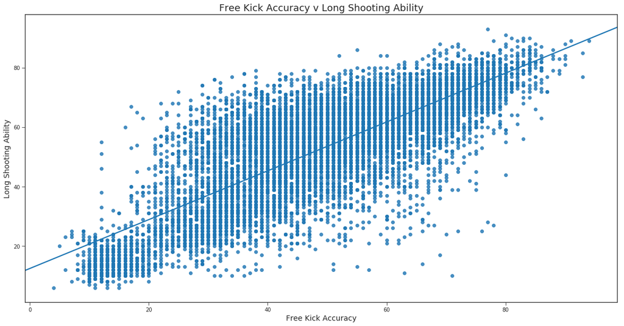

```python
# Create the figure
fig = plt.figure(figsize=(20,10))
ax = fig.add_subplot(111)

# Generate the values
x_vals = df1.free_kick_accuracy
y_vals = df1.long_shots

# Plot the values
ax.scatter(x_vals, y_vals, c = 'b', marker='o', s=0.05)
sns.regplot(x_vals, y_vals, ci=None)
ax.set_xlabel('Free Kick Accuracy', fontsize = 14)
ax.set_ylabel('Long Shooting Ability', fontsize = 14)
ax.set_title('Free Kick Accuracy v Long Shooting Ability', fontsize = 18)

plt.show()
```

### Research Question 2 - Is there a relationship between acceleration, height, weight?

In this question I will try to test whether there is a relationship between acceleration, height and weight by plotting a scatter chart for all columns. A correlation matrix is created for all three variables.

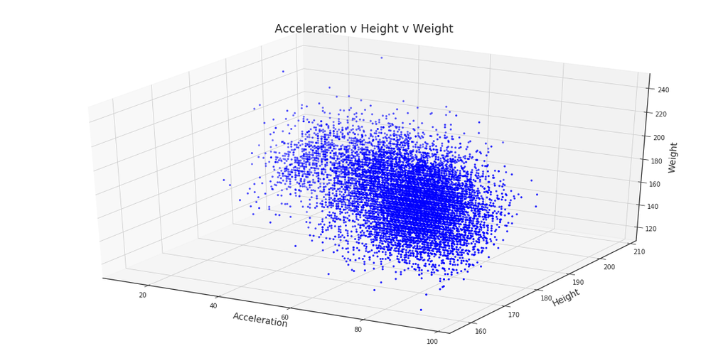

```python
# Create the figure
fig = plt.figure(figsize=(20,10))
ax = fig.add_subplot(111, projection='3d')

# Generate the values
x_vals = df1.acceleration
y_vals = df1.height
z_vals = df1.weight

# Plot the values
ax.scatter(x_vals, y_vals, z_vals, c = 'b', marker='o', s=5)
ax.set_xlabel('Acceleration', fontsize = 14)
ax.set_ylabel('Height', fontsize = 14)
ax.set_zlabel('Weight', fontsize = 14)
ax.set_title('Acceleration v Height v Weight', fontsize = 18)

plt.show()
```

```python
#calculating correlation matrix between all 3 variables
np.corrcoef([df1.acceleration, df1.height, df1.weight])
```

```
array([[ 1.        , -0.53559186, -0.50554987],
       [-0.53559186,  1.        ,  0.76662585],
       [-0.50554987,  0.76662585,  1.        ]])
```

Scatterplot and correlation matrix show a moderate relationship between acceleration and height/weight. On the other hand, as expected, we have a strong correlation between height and weight.

In this question I look to discover which teams obtained the most points per game during the 2012/13 - 2015/16 seasons. In my research I will exclude teams which played fewer than 15 games per season. Teams which don't have data for each consecutive season will also be omitted.

```python
df2_WDL.describe()
```

|  | team_api_id | wins | losses | draws | games_played | points | points_per_game |
| --- | --- | --- | --- | --- | --- | --- | --- |
| count | 733.000000 | 733.000000 | 733.000000 | 733.000000 | 733.000000 | 733.000000 | 733.000000 |
| mean | 11006.564802 | 13.122783 | 13.158254 | 8.976808 | 35.257844 | 48.345157 | 1.370323 |
| std | 20474.930847 | 5.633010 | 5.139800 | 2.875990 | 3.453490 | 16.181758 | 0.434118 |
| min | 1601.000000 | 1.000000 | 1.000000 | 1.000000 | 6.000000 | 4.000000 | 0.447368 |
| 25% | 8455.000000 | 9.000000 | 10.000000 | 7.000000 | 34.000000 | 38.000000 | 1.078947 |
| 50% | 8689.000000 | 12.000000 | 14.000000 | 9.000000 | 37.000000 | 45.000000 | 1.289474 |
| 75% | 9925.000000 | 16.000000 | 17.000000 | 11.000000 | 38.000000 | 57.000000 | 1.631579 |
| max | 274581.000000 | 33.000000 | 28.000000 | 18.000000 | 38.000000 | 102.000000 | 2.684211 |

```python
#filtering out teams that played less than 15 games per season
df_MG = df2_WDL.drop(df2_WDL[df2_WDL.games_played < 15].index)
df=df_MG.groupby('team_long_name', as_index = False).count()

#dropping teams which don't have data for all 4 seasons
df=df.drop(df[df.season < 4].index)
columns = ['team_api_id','wins','season','losses','draws','points','games_played','points_per_game']
df.drop(columns, inplace=True, axis=1)
df_all_seasons=pd.merge(df2_WDL, df,  how='inner', on='team_long_name')
df_all_seasons.head()
```

|  | team_api_id | season | team_long_name | wins | losses | draws | games_played | points | points_per_game |
| --- | --- | --- | --- | --- | --- | --- | --- | --- | --- |
| 0 | 1601 | 2012/2013 | Ruch Chorzów | 8 | 15 | 7 | 30 | 31 | 1.033333 |
| 1 | 1601 | 2013/2014 | Ruch Chorzów | 14 | 8 | 8 | 30 | 50 | 1.666667 |
| 2 | 1601 | 2014/2015 | Ruch Chorzów | 8 | 13 | 9 | 30 | 33 | 1.100000 |
| 3 | 1601 | 2015/2016 | Ruch Chorzów | 11 | 13 | 6 | 30 | 39 | 1.300000 |
| 4 | 1957 | 2012/2013 | Jagiellonia Białystok | 8 | 9 | 13 | 30 | 37 | 1.233333 |

```python
#sorting by Team name and getting average points by game
df_all_seasons.groupby('team_long_name').mean().sort_values(by='points_per_game', ascending=False).head()
```

| team_long_name | team_api_id | wins | losses | draws | games_played | points | points_per_game |
| --- | --- | --- | --- | --- | --- | --- | --- |
| FC Bayern Munich | 9823.0 | 27.75 | 2.50 | 3.75 | 34.0 | 87.00 | 2.558824 |
| SL Benfica | 9772.0 | 25.75 | 2.50 | 3.75 | 32.0 | 81.00 | 2.530392 |
| FC Barcelona | 8634.0 | 29.50 | 4.00 | 4.50 | 38.0 | 93.00 | 2.447368 |
| Juventus | 9885.0 | 28.75 | 3.75 | 5.50 | 38.0 | 91.75 | 2.414474 |
| Celtic | 9925.0 | 27.50 | 4.00 | 6.50 | 38.0 | 89.00 | 2.342105 |

## Conclusions

**Question 1**

> From Question 1 we concluded that left footed players have a better free kick accuracy than right footed players. One limitation from this quick research was that I had duplicate data and didn't consider instances where certain players improve their free kick score.

> Traditionally free kick takers are usually also very good at long shots and therefore it is was worth finding out the correlation between both variables. My research concluded a strong correlation between free kick taking and long shooting. It was noticed that some players have a good shooting ability but a very poor free kick accuracy. This data could be effected by the fact that these players don't usually take free kicks due to not playing or simply they are not regular free kick takers.

**Question 2**

> In research Question 2 I tried to find a relationship between acceleration, height and weight. From the data it was evident that a strong correlation exists between height and weight which is understandable. On the other hand, the relationship between acceleration and height/weight was moderate.

> Taking other variables into consideration such as the playing position might also answer why certain players have lower acceleration than average. For example acceleration for GKs is not a priority and therefore this data is more prone to be inaccurate.

**Question 3**

> In my final question I found out the best teams based on points per game during the 2012/13 - 2015/16 seasons are: FC Bayern Munich, SL Benfica, FC Barcelona, Juventus and Celtic.

> I only considered teams that played a minimum of 15 games per season for each of the 4 different seasons.

## References

> www.stackoverflow.com

```python
from subprocess import call
call(['python', '-m', 'nbconvert', 'Investigate_a_Dataset.ipynb'])
```

```
0
```